# TidyVerse Create ggplot2

Adam Gersowitz

3/27/2020

## Using ggplot2::geom_polygon in Visual Context

By using the tidyverse, we can reduce the dependent library calls required downstream.

```r
library(tidyverse)
```

## Load information from 538 on Information on Foul Balls in the MLB

In this section I bring in a dataset from 538 that contains information on MLB fould balls. In this analysis I would like to look at the number of balls and the average exit velocity of balls that reach the stands in baseball. I acquire these summary statistics after removing records that do not have an exit velocity or would not have reached the stands.

Having extended the original version of this to make use of the `dplyr` library, we can use piping and various manipulation verbs to achieve the same effects as before. Because we’ve used `readr::read_csv`, we no longer can to filter for `exit_velocity != "NA"` (we’d use `is.na()` instead) and then roll our original conditions `type_of_hit != "Ground"` and `type_of_hit != "Batter hits self"` into a single membership test). This also reduces our lines nicely.

```r
foul <- read_csv("https://raw.githubusercontent.com/agersowitz/Data-607-Datasets/master/foul-balls%5B1%5D.csv")
foul <- foul %>% filter(!type_of_hit %in% c("Ground", "Batter hits self"))

foulev <- foul %>% filter(!is.na(exit_velocity))
```

Similarly, we can replace the original SQL-style group aggregation with the tidyverse way of doing it.

```r
avg_exit <- group_by(foulev, used_zone) %>% summarize(aev = mean(exit_velocity))
count_hit <- count(foulev, used_zone, name = "cev")
```

## Mapping this data to the rough outline of a baseball diamond

In this final section I use various ggplot functions to create a baseball diamond based on an x,y plot. I roughly based the sections off of the graphic found at https://fivethirtyeight.com/features/we-watched-906-foul-balls-to-find-out-where-the-most-dangerous-ones-land/

Replacing the usual work of dataframes with tibbles makes things easier on our end when working in the console. Creating a new vector to produce a set of IDs is handy, but the mutate function lets us leverage existing structures.

```r
simple_mutate <- function(x) {
  mutate_at(x, "used_zone", factor) %>% rename("id" = "used_zone")
}

ev <- simple_mutate(avg_exit)
ch <- simple_mutate(count_hit)

positions <- tibble(
  id = rep(ev$id, each = 5),
  x = c(
        -0.25, -0.5, 0.5, 0.25, 0,
        -0.25,-0.5, -0.75, -0.5,-0.5,
        0.25,0.5, 0.75, 0.5,0.5,
        -0.5, -0.75, -1,-0.75,-0.75,
        0.5, 0.75, 1,0.75,0.75,
        -0.75, -1, -1,-1,-1,
        0.75, 1, 1,1,1)
  ,
  y = c(
        -0.75, -1, -1, -0.75, -1,
        -0.75, -0.5, -0.75, -1, -1,
        -0.75, -0.5, -0.75, -1, -1,
        -0.5, -0.75, -0.25, -0.25,-0.25,
        -0.5, -0.75, -0.25, -0.25,-0.25,
        -0.25, -.25, 0, 0, 0,
        -0.25, -.25, 0, 0, 0)
)
```

The `dplyr` package includes a variety of join functions that make the join-type employed explicit to the reader, versus the base `merge` function.

```r
datapoly <- inner_join(ev, positions, by = "id")
datapolych <- inner_join(ch, positions, by = "id")
```

Because the goal we have to is to create two essentially identical geometries (they accord with a baseball diamond), we can create a function to handle our `ggplot2` calls. Using `aes_string` is an easy way to make flexible functions within the plotting realm, as it permits you to pass arguments as strings and avoid the (sometimes) confusing world of quosures.

```r
geom_baseball <- function(dataframe, fill_value, low_color, high_color,
                          label_list) {
  ggplot(dataframe, aes_string("x", "y")) +
    geom_polygon(aes_string(fill = fill_value, group = "id")) +
    geom_line(data = baseline, color = "grey30", size = 2) +
    scale_fill_gradient(low = low_color, high = high_color) +
    labs(title = label_list$title, x = label_list$x, y = label_list$y,
         fill = label_list$legend) +
    theme(axis.text.x = element_blank(),
          axis.ticks.x = element_blank(),
          axis.text.y = element_blank(),
          axis.ticks.y = element_blank())
}

baseline <- tibble(x = c(-1,0,1), y = c(0,-1,0))

pev_labs <- list(title = "Average Exit Velocity of Foul Balls by Seating Zone",
                 x = "", y = "", legend = "Avg. Exit Velocity")
pch_labs <- list(title = "Number of Foul Balls by Seating Zone",
                 x = "", y = "", legend = "Number of Foul Balls")
```

Having set definitions for both the type of graphic we’re producing and a helper tibble to achieve the desired results, it becomes a lot easier to produce and display our visual. By taking out the axis text and ticks using `theme()`, we can achieve a much simpler version that focuses solely on the geometric figure.

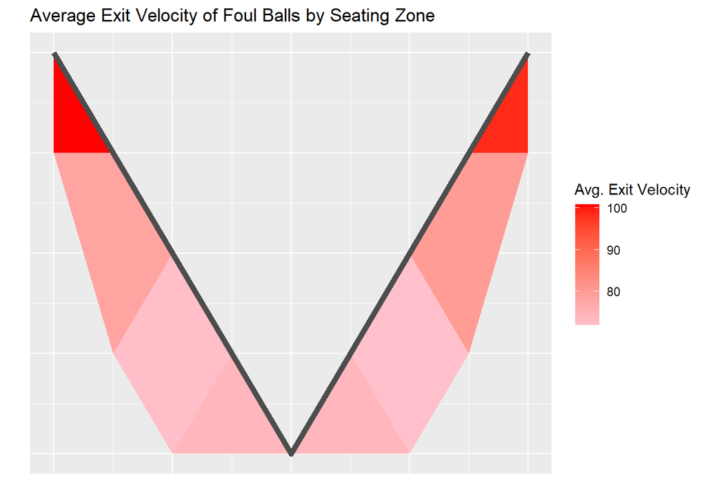

```r
(pev <- geom_baseball(datapoly, "aev", "pink", "red", pev_labs))
```

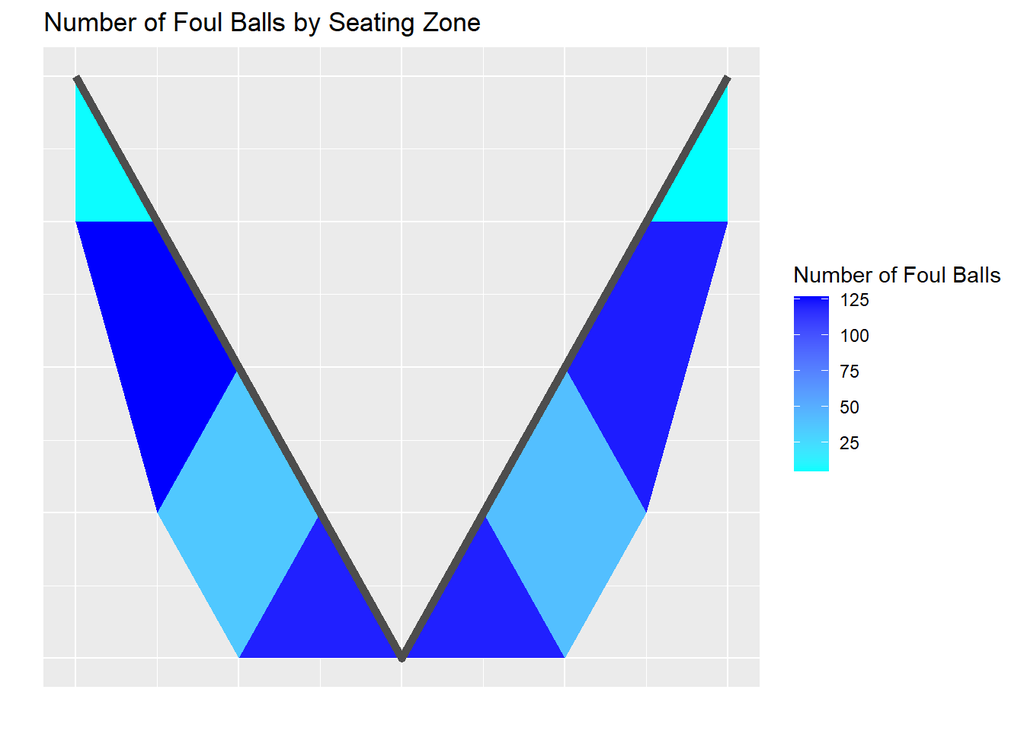

```r
(pch <- geom_baseball(datapolych, "cev", "cyan", "blue", pch_labs))
```

## Conclusion

By the end of this analysis you can visualy see statistics on fould balls in MLB. This can be very useful when trying to convey information that has a physical correlation to people who aren’t data scientists. For example population data on a map based on county or a blueprint of a building that shows where certain problems are occurring with certain tenants.